# R Notebook

# Question 1 - Load the data, clean_names() and explore it.

| asin | brand | title | url | image | rating | review_url | total_reviews | prices |
| --- | --- | --- | --- | --- | --- | --- | --- | --- |
| B0000SX2UC | Nokia | Dual-Band / Tri-Mode Sprint PCS Phone w/ Voice Activated Dialing & Bright White Backlit Screen | https://www.amazon.com/Dual-Band-Tri-Mode-Activated-Dialing-Backlit/dp/B0000SX2UC | https://m.media-amazon.com/images/I/2143EBQ210L._AC_UY218_SEARCH213888_FMwebp_QL75_.jpg | 3.0 | https://www.amazon.com/product-reviews/B0000SX2UC | 14 | NA |
| B0009N5L7K | Motorola | Motorola I265 phone | https://www.amazon.com/Motorola-i265-I265-phone/dp/B0009N5L7K | https://m.media-amazon.com/images/I/419WBAVDARL._AC_UY218_SEARCH213888_FMwebp_QL75_.jpg | 2.9 | https://www.amazon.com/product-reviews/B0009N5L7K | 7 | $49.95 |
| B000SKTZ0S | Motorola | MOTOROLA C168i AT&T CINGULAR PREPAID GOPHONE CELL PHONE | https://www.amazon.com/MOTOROLA-C168i-CINGULAR-PREPAID-GOPHONE/dp/B000SKTZ0S | https://m.media-amazon.com/images/I/71b+q3ydkIS._AC_UY218_SEARCH213888_FMwebp_QL75_.jpg | 2.6 | https://www.amazon.com/product-reviews/B000SKTZ0S | 22 | NA |
| B00198M12M | Nokia | Nokia 6500 Slide Black/silver Unlocked Cell Phone | https://www.amazon.com/Nokia-6500-Slide-silver-Unlocked/dp/B00198M12M | https://m.media-amazon.com/images/I/41ss4HpLkLL._AC_UY218_SEARCH213888_FMwebp_QL75_.jpg | 2.4 | https://www.amazon.com/product-reviews/B00198M12M | 5 | NA |
| B001AO4OUC | Motorola | Motorola i335 Cell Phone Boost Mobile | https://www.amazon.com/Motorola-i335-Phone-Boost-Mobile/dp/B001AO4OUC | https://m.media-amazon.com/images/I/710UO8gdT+L._AC_UY218_SEARCH213888_FMwebp_QL75_.jpg | 3.3 | https://www.amazon.com/product-reviews/B001AO4OUC | 21 | NA |
| B001DCJAJG | Motorola | Motorola V365 no contract cellular phone AT&T | https://www.amazon.com/Motorola-V365-contract-cellular-phone/dp/B001DCJAJG | https://m.media-amazon.com/images/I/61LYNCVrrKL._AC_UY218_SEARCH213888_FMwebp_QL75_.jpg | 3.2 | https://www.amazon.com/product-reviews/B001DCJAJG | 12 | NA |

We have data on mobile phone models, including a rating score, total number of reviews given and price.

# Question 2 - Find the brand with the highest numbers of phones in the dataset

| brand | total_phones |
| --- | --- |
| Samsung | 397 |
| Apple | 101 |
| Motorola | 100 |
| Nokia | 49 |
| HUAWEI | 36 |
| Google | 33 |
| Sony | 29 |
| Xiaomi | 27 |
| ASUS | 13 |
| OnePlus | 7 |

# Question 3 -

For your top brand, plot the distribution of phone ratings as a probability density, overlaying a fitted normal distribution. Do you think the normal distribution provides a good model of these ratings?

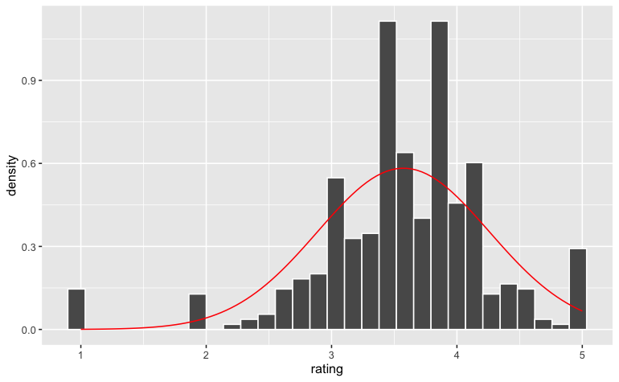

I believe that the normal distribution does provide an ok model for the ratings. Because: - We see that the data is unimodal spread - Its highest peak, does overlap with the peak of the normal distribution curve, eventhough two bins particularly have a higher density than the rest. But this equals out with near bins being lower. - Data shows some left skewed spread, due to an outlier, but this is somewhat compensated by a higher peak on the left hand side of the curve.

# Question 4

```r
# Expected proportions of a normal distribution are:
  #1sd:
  pnorm(1) - pnorm(-1)
```

```
[1] 0.6826895
```

# Extension

```r
 phones %>%
  filter(brand == "Samsung") %>%
  qqplot()
```

```
Error in xtfrm.data.frame(x) : cannot xtfrm data frames
```